# Final Project

James Grandin

12/3/2021

In this project, we are tasked with building a classification model that attempts to find predit wether Ozone levels are high or low given particular conditions. One of the simplest and most powerful classification algorithms for building such a model is logistic regression. In general,logistic regression is limited to 2 classes, which is perfect for this problem. If mroe classes were necessary, we could use an alternative algorith, such as decision trees. Logisitic regression models that probability of a certain binomial event exisiting. Its possible to model multiple classes via certain extensions, but that is beyond the scope of this project.

Data Collection

First, we must read in the data. For this project, we were given a dataset, but in real life, we may need to create a data pipeline that cleans and standardizes that data for better model performance.

```r
data <- read.csv("~/Desktop/Machine Learning 1/Final Project/ozone-data.csv")

head(data)
```

|  | NitricOxide | NitrogenDioxide | OxidesofNitrogen | WindSpeed | ResultantWindSpeed | ResultantWindDirection | MaximumWindGust | Std.Dev.WindDirection | OutdoorTemperature | DewPointTemperature | RelativeHumidity | SolarRadiation | PM10 | Ozone |
| --- | --- | --- | --- | --- | --- | --- | --- | --- | --- | --- | --- | --- | --- | --- |
| 1 | -0.2 | 1.7 | 1.6 | 9.2 | 9.0 | 83 | 17.8 | 14 | 79.7 | 51.1 | 37.0 | 0.047 | 31.3 | 0 |
| 2 | 0.8 | 9.2 | 10.0 | 3.8 | 2.0 | 221 | 8.6 | 56 | 85.7 | 43.9 | 23.3 | 1.209 | 66.2 | 1 |
| 3 | 0.5 | 4.0 | 4.5 | 12.9 | 12.2 | 92 | 25.4 | 20 | 93.1 | 45.8 | 19.8 | 0.896 | 35.9 | 0 |
| 4 | 1.1 | 26.9 | 28.1 | 4.4 | 4.1 | 116 | 9.4 | 20 | 90.2 | 34.2 | 13.8 | 0.000 | 50.8 | 0 |
| 5 | 0.1 | 3.6 | 3.7 | 8.5 | 8.1 | 287 | 17.9 | 19 | 90.7 | 44.8 | 20.7 | 0.000 | 13.7 | 0 |
| 6 | 0.7 | 5.6 | 6.2 | 6.5 | 5.5 | 145 | 15.0 | 32 | 102.1 | 6.0 | 2.9 | 0.713 | 31.0 | 1 |

```r
tail(data)
```

|  | NitricOxide | NitrogenDioxide | OxidesofNitrogen | WindSpeed | ResultantWindSpeed | ResultantWindDirection | MaximumWindGust | Std.Dev.WindDirection | OutdoorTemperature | DewPointTemperature | RelativeHumidity | SolarRadiation | PM10 | Ozone |
| --- | --- | --- | --- | --- | --- | --- | --- | --- | --- | --- | --- | --- | --- | --- |
| 968 | 0.2 | 1.5 | 1.7 | 9.1 | 8.8 | 301 | 21.1 | 16 | 54.5 | 33.4 | 44.8 | 0.000 | 9.4 | 0 |
| 969 | -0.1 | -0.1 | -0.2 | 7.4 | 6.8 | 269 | 16.5 | 23 | 73.5 | 60.8 | 64.6 | 0.000 | 14.3 | 0 |
| 970 | 0.5 | 4.3 | 4.8 | 6.8 | 5.7 | 94 | 16.9 | 33 | 90.1 | 51.0 | 26.5 | 1.409 | 25.2 | 1 |
| 971 | 0.1 | 8.9 | 9.0 | 4.9 | 4.6 | 98 | 10.4 | 20 | 92.8 | 32.8 | 12.0 | 0.000 | 37.0 | 0 |
| 972 | -0.3 | 3.2 | 3.1 | 4.6 | 1.8 | 144 | 12.0 | 63 | 84.7 | 41.5 | 22.4 | 1.406 | 10.5 | 1 |
| 973 | 0.6 | 0.8 | 1.4 | 9.3 | 7.8 | 251 | 23.9 | 32 | 85.7 | 21.6 | 9.6 | 1.507 | 21.2 | 0 |

```r
any(is.na(data))
```

```
## [1] FALSE
```

```r
dim(data)
```

```
## [1] 973  14
```

```r
str(data)
```

```
## 'data.frame':    973 obs. of  14 variables:
##  $ NitricOxide           : num  -0.2 0.8 0.5 1.1 0.1 0.7 0.6 0 0.2 8.7 ...
##  $ NitrogenDioxide       : num  1.7 9.2 4 26.9 3.6 5.6 2.8 1.3 5.5 16.9 ...
##  $ OxidesofNitrogen      : num  1.6 10 4.5 28.1 3.7 6.2 3.4 1.3 5.7 25.2 ...
##  $ WindSpeed             : num  9.2 3.8 12.9 4.4 8.5 6.5 5 4 5.5 5.3 ...
##  $ ResultantWindSpeed    : num  9 2 12.2 4.1 8.1 5.5 3.8 2.7 5.3 5.2 ...
##  $ ResultantWindDirection: int  83 221 92 116 287 145 163 286 308 286 ...
##  $ MaximumWindGust       : num  17.8 8.6 25.4 9.4 17.9 15 10.5 11.3 10.9 11.5 ...
##  $ Std.Dev.WindDirection : int  14 56 20 20 19 32 40 47 16 14 ...
##  $ OutdoorTemperature    : num  79.7 85.7 93.1 90.2 90.7 ...
##  $ DewPointTemperature   : num  51.1 43.9 45.8 34.2 44.8 6 52.3 27.1 48.5 35.7 ...
##  $ RelativeHumidity      : num  37 23.3 19.8 13.8 20.7 2.9 30.9 9.6 27.2 34.7 ...
##  $ SolarRadiation        : num  0.047 1.209 0.896 0 0 ...
##  $ PM10                  : num  31.3 66.2 35.9 50.8 13.7 31 31.9 23.9 22.9 28.4 ...
##  $ Ozone                 : int  0 1 0 0 0 1 1 1 0 0 ...
```

Exploratory Data Anaylsis

We can find out alot about a dataset from EDA. In this case barplots, boxplots, and histograms were used to visualize the data. These plots are useful in finding obvious patterns that can not be seen by simply looking at the raw numbers.

Interesting Findings:

1. This dataset contains 60% more low ozone days than high ozone days, as seen by the frequency table.
2. high Ozone days seem to be more likely on days when relative humidity is between 12% and 20%.
3. Nitric Oxide and Wind Speed seem to be strongly associated with high ozone, having very small P values.

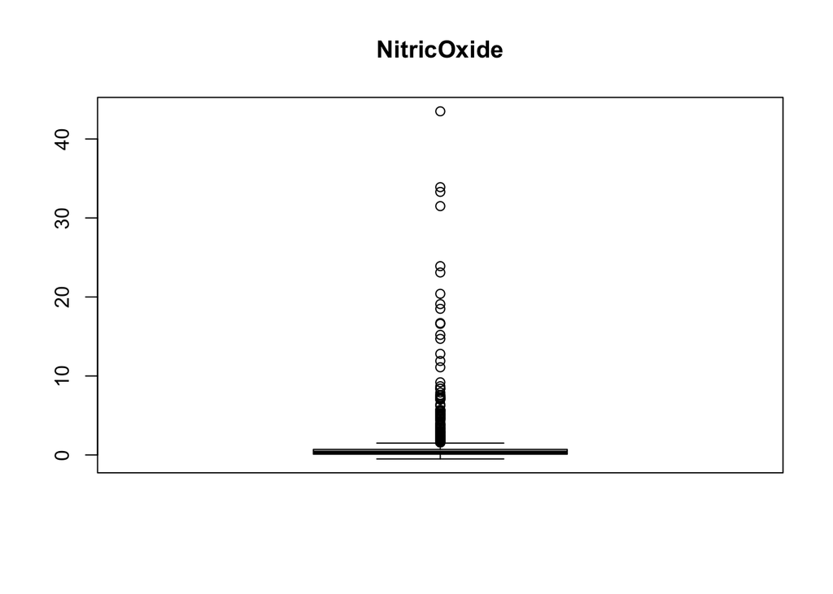

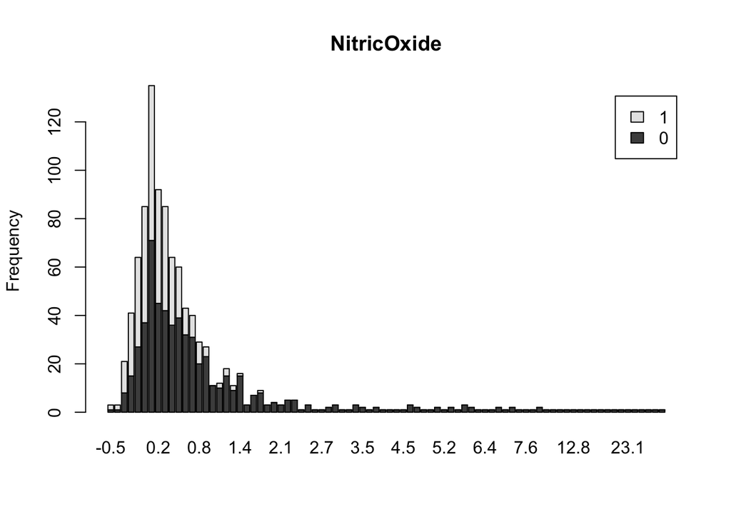

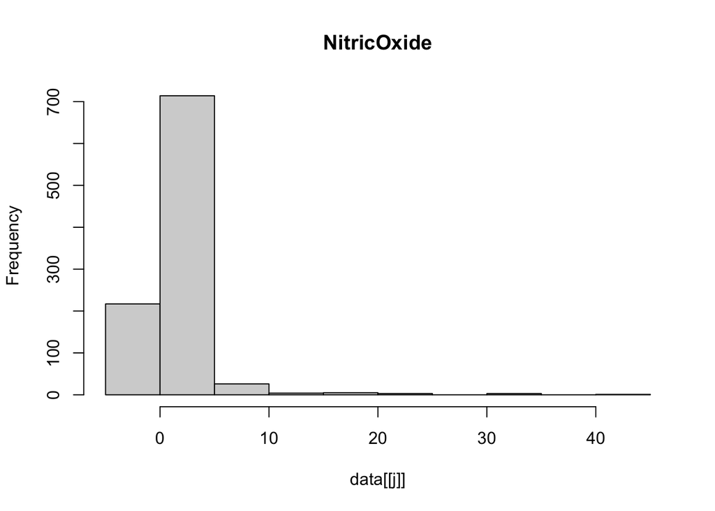

```
## [1] "NitricOxide"          "4.68957001427892e-32" "Association"
```

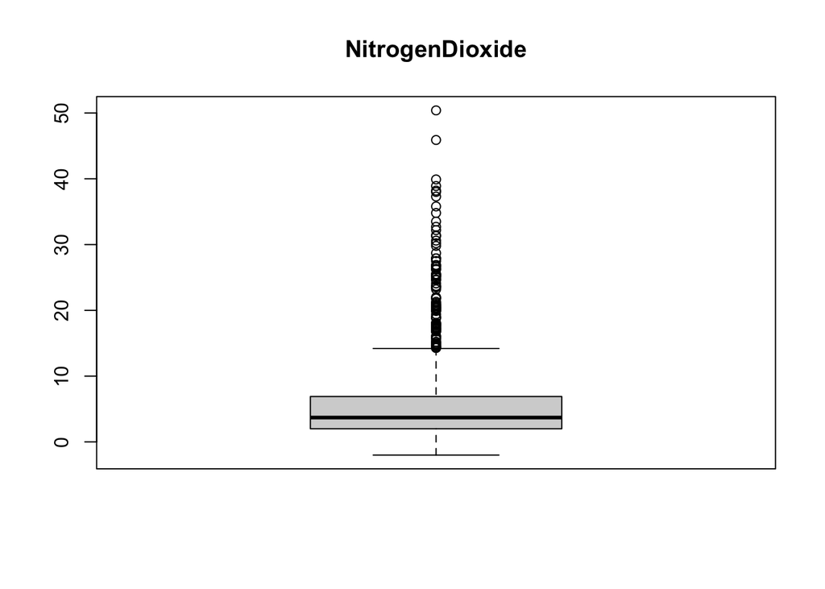

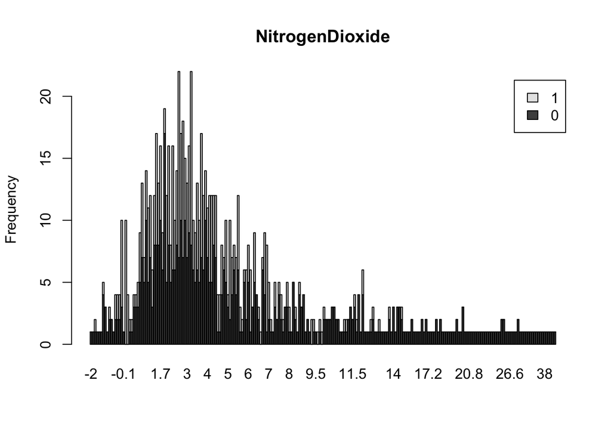

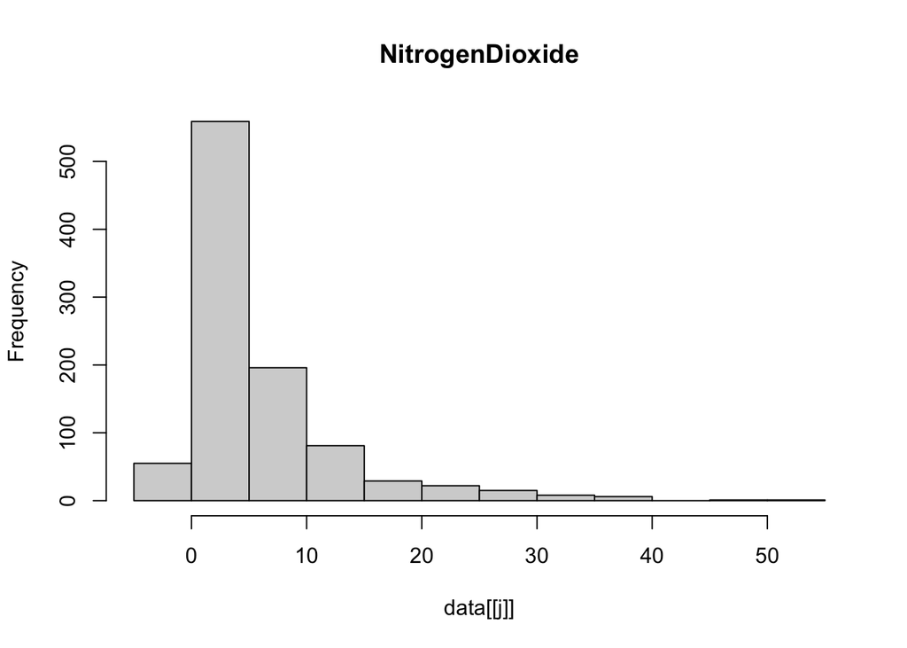

```
## [1] "NitrogenDioxide"      "9.62181751292068e-11" "Association"
```

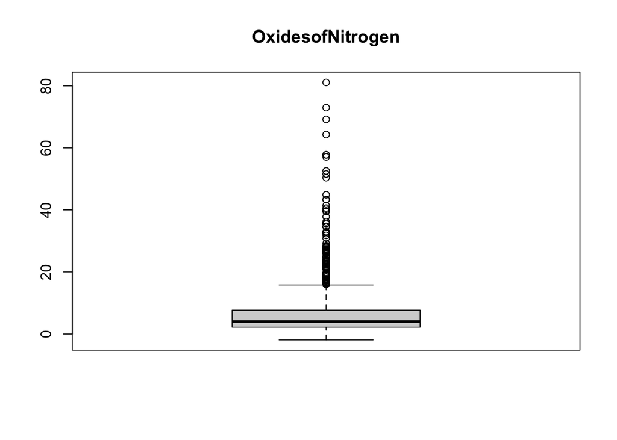

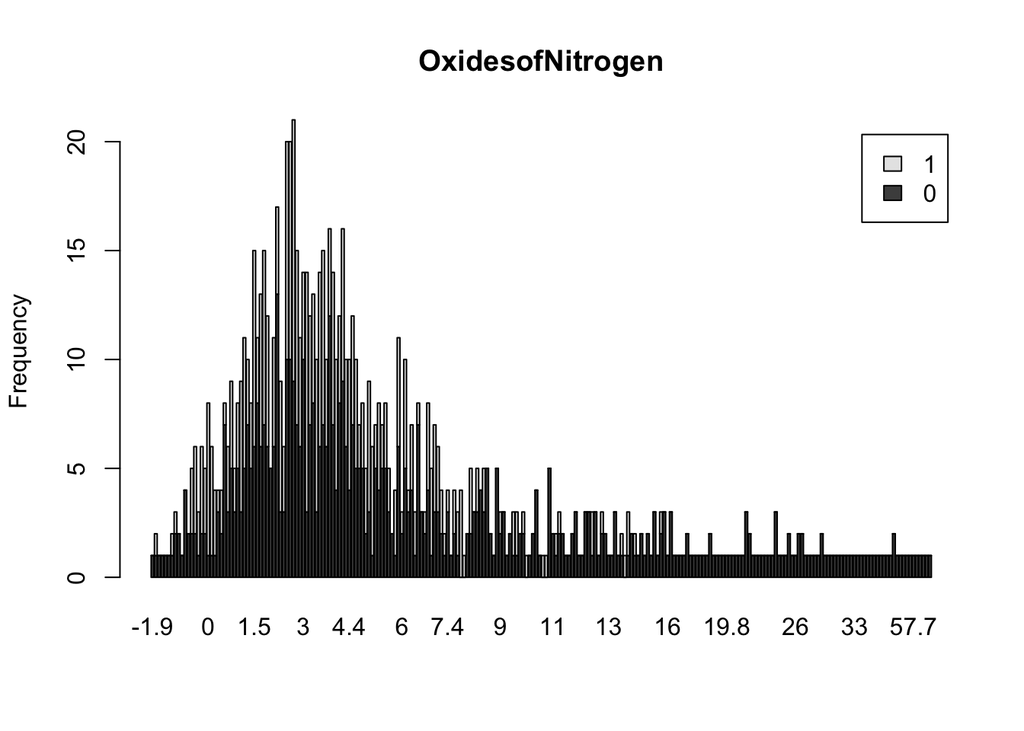

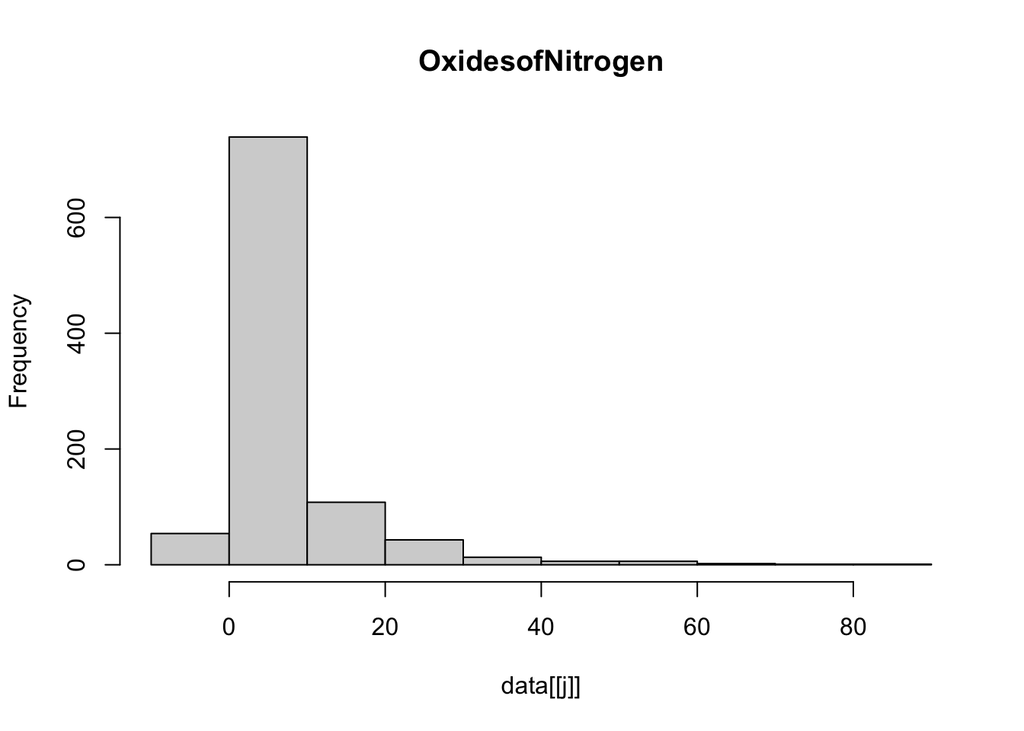

```
## [1] "OxidesofNitrogen"     "2.22341240146661e-14" "Association"
```

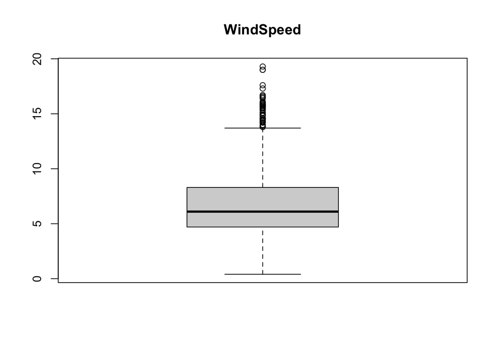

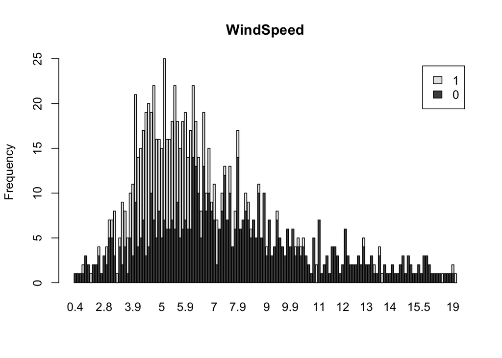

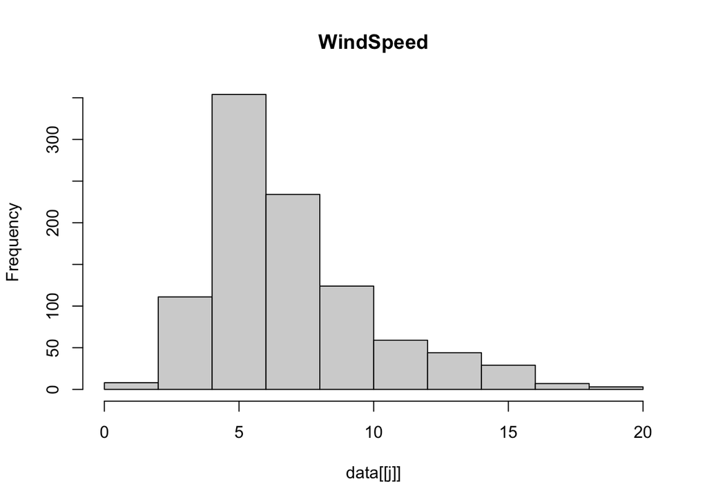

```
## [1] "WindSpeed"            "4.95836543969313e-39" "Association"
```

[24 more figures not shown]

```
## [1] "Ozone"                 "1.92501722266983e-280" "Association"
```

```r
###### EDA ########
for (j in 1:ncol(data)){

  if (class(data[[j]]) == "numeric") {
    par(mfrow=c(1,1))
    boxplot(data[[j]], main = colnames(data[j]))
    table <-table(data$Ozone,data[[j]])
    barplot(table,legend.text=rownames(table), main = colnames(data[j]),
            ylab = "Frequency", width=(length(data[[j]]/20)))
    hist(data[[j]], main = colnames(data[j]))

    #pull only pvalue from the wilcox test save space in the console
    pVal = wilcox.test(data[[j]]~data$Ozone, alternative = 'two.sided')$p.value

    if (pVal<=0.05){A = "Association"}else{A="No Association"}
    print(c(colnames(data[j]),pVal,A))  #print list with variable, pvalue, and association

  } else { table <-table(data$Ozone,data[[j]])

    barplot(table,legend.text=rownames(table), main = colnames(data[j]), ylab = "Frequency", las =2)

    table2 <-table(data[[j]],data$Ozone,useNA="no")
    pVal2 <- fisher.test(table2, simulate.p.value =TRUE)$p.value

    if (pVal2<=0.1){B = "Association"}else{B="No Association"}
    print(c(colnames(data[j]),pVal2,B))
  }
}
```

In this step, we split the dataset into the training, validation, and testing data necessary to properly build the model.

```r
# Data partition
set.seed(123)
n <- nrow(data)
id.split <- sample(x=1:3, size = n, replace =TRUE, prob=c(0.50, 0.25, 0.25))
data.train <- data[id.split ==1, ]
data.validate <- data[id.split == 2, ]
data.test <- data[id.split == 3, ]

# Predictor variables
X.train <- model.matrix(as.formula(factor(Ozone)~.), data= data.train)[, -1]
X.validate <- model.matrix(as.formula(factor(Ozone)~.), data= data.validate)[, -1]
X.test <- model.matrix(as.formula(factor(Ozone)~.), data= data.test)[, -1]

# Outcome variable
y.train <- data.train$Ozone
y.validate <- data.validate$Ozone
y.test <- data.test$Ozone


data.pooled <- rbind(data.train,data.validate)
X.pooled<- model.matrix(as.formula(factor(Ozone)~.), data= data.pooled)[, -1]
y.pooled<-data.pooled$Ozone
# Will be using lasso regression to filter out uncorrelated variables
# This makes the model more simple and readable
#binomial means we are using Logistic Regression which is a much better
#classifier algorithm compared to linear regression
```

Model Building

```r
library(glmnet)
Lambda <- seq(0.001, 0.5, length.out = 500)

L <- length(Lambda)

OUT <- matrix (0, L, 3)

for (i in 1:L){
  #fitting the lasso logistic regression model to the training data
  fit <- glmnet(x=X.train, y=y.train, family ="binomial", alpha =1, #lasso
                lambda=Lambda[i], standardize=T, thresh = 1e-07, maxit=1000)
  #using model to on validation data to determine the best lambda
  pred <- predict(fit, newx=X.validate, s=Lambda[i], type="response")
  miss.rate <- mean(y.validate != (pred > 0.5))
  mse <- mean((y.validate - pred)^2)
  OUT[i, ] <- c(Lambda[i], miss.rate, mse)

}
```

Finding Optimum Penalty Value

According to the MSE and the Missclassification Rate plot, the Lambda that offers the smallest MSE and Missrate is 0.001 or the smallest lambda. This suggests that only a very small penalty is needed (if one is needed at all) in order to properly model this data, meaning the data does not have enough variance as to effect the results of the algorithm.

```r
# print the MSE, Missclassification rate table corresponding lambda
head(OUT)
```

```
##       [,1]      [,2]      [,3]
## [1,] 0.001 0.1522634 0.1049999
## [2,] 0.002 0.1646091 0.1059753
## [3,] 0.003 0.1646091 0.1076269
## [4,] 0.004 0.1604938 0.1090547
## [5,] 0.005 0.1646091 0.1103811
## [6,] 0.006 0.1646091 0.1118129
```

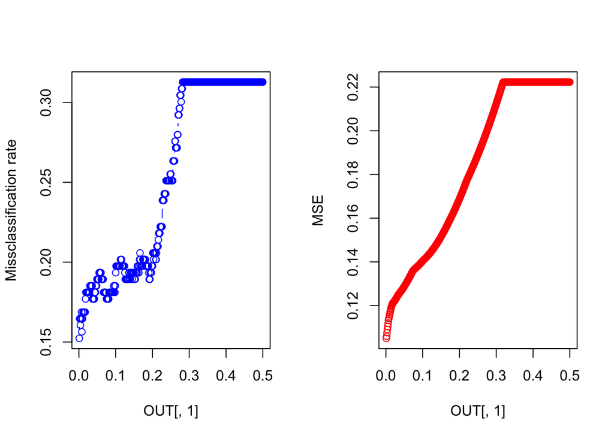

```r
par(mfrow = c(1,2))
plot(OUT[, 1], OUT[,2], type = "b", col = "blue", ylab = "Missclassification rate")
plot(OUT[, 1], OUT[,3], type = "b", col = "red", ylab = "MSE")
```

```r
lambda.best <- OUT[which.min(OUT[, 3]), 1]
miss.rate_Lambda <- OUT[which.min(OUT[, 3]), 2]
```

Final Best Fit Model

```r
fit.best <- glmnet (x=X.pooled, y=y.pooled, family ="binomial", alpha=1,  #LASSO
                    lambda = lambda.best, standardize = T, thresh = 1e-07, maxit=1000)
names(fit.best)
```

```
##  [1] "a0"         "beta"       "df"         "dim"        "lambda"
##  [6] "dev.ratio"  "nulldev"    "npasses"    "jerr"       "offset"
## [11] "classnames" "call"       "nobs"
```

```r
fit.best$beta # Finding important variables.
```

```
## 13 x 1 sparse Matrix of class "dgCMatrix"
##                                  s0
## NitricOxide            -2.431465636
## NitrogenDioxide         .
## OxidesofNitrogen       -0.014435555
## WindSpeed              -0.333079895
## ResultantWindSpeed      .
## ResultantWindDirection -0.003608276
## MaximumWindGust        -0.030567470
## Std.Dev.WindDirection   0.054710532
## OutdoorTemperature     -0.035569907
## DewPointTemperature     0.069186366
## RelativeHumidity       -0.175153467
## SolarRadiation          1.655857976
## PM10                    0.013498386
```

```r
pred <- predict(fit.best, newx = X.test, s =lambda.best, type="response")
dim(pred)
```

```
## [1] 238   1
```

Evaluation:

```r
miss.rate <- mean(y.test != (pred > 0.5))
mse <- mean((y.test - pred)^2)

mse
```

```
## [1] 0.06047683
```

```r
miss.rate
```

```
## [1] 0.07563025
```

```r
library(cvAUC)
yobs <- y.test
AUC <- ci.cvAUC(predictions = pred, labels =yobs, folds=1:NROW(data.test), confidence = 0.95)
AUC
```

```
## $cvAUC
## [1] 0.9715256
##
## $se
## [1] 0.01000722
##
## $ci
## [1] 0.9519118 0.9911394
##
## $confidence
## [1] 0.95
```

```r
auc.ci <- round(AUC$ci, digits = 3)

library(verification)
mod.glm <- verify(obs = yobs, pred = pred)
```

```
## If baseline is not included, baseline values  will be calculated from the  sample obs.
```

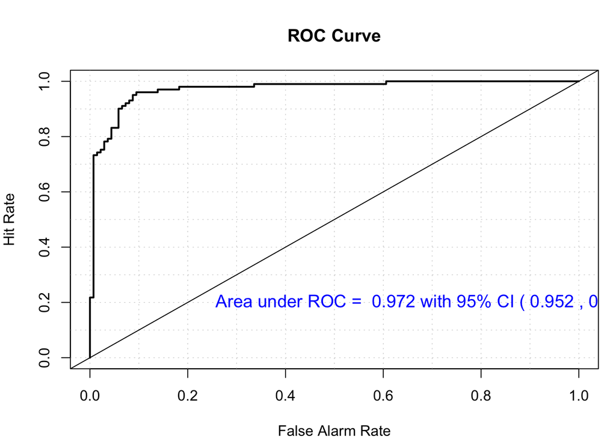

```r
roc.plot(mod.glm, plot.thres=NULL)
text(x=0.7, y=0.2, paste("Area under ROC = ", round(AUC$cvAUC, digits = 3), "with 95% CI (",
                         auc.ci[1], ",", auc.ci[2], ").", sep = " "), col="blue", cex =1.2)
```

```r
library(caret)
pred1 <- ifelse(pred>0.5, 1, 0)
confusionMatrix(factor(pred1), factor(y.test))
```

```
## Confusion Matrix and Statistics
##
##           Reference
## Prediction   0   1
##          0 125   6
##          1  12  95
##
##                Accuracy : 0.9244
##                  95% CI : (0.8831, 0.9546)
##     No Information Rate : 0.5756
##     P-Value [Acc > NIR] : <2e-16
##
##                   Kappa : 0.8464
##
##  Mcnemar's Test P-Value : 0.2386
##
##             Sensitivity : 0.9124
##             Specificity : 0.9406
##          Pos Pred Value : 0.9542
##          Neg Pred Value : 0.8879
##              Prevalence : 0.5756
##          Detection Rate : 0.5252
##    Detection Prevalence : 0.5504
##       Balanced Accuracy : 0.9265
##
##        'Positive' Class : 0
##
```

OVerall, this model performed exceedingly well. This is likely because we had very clean data filled with features that were highly correlated to the target variable. In other cases, we may not be able to generate a model with such great prediction capabilities.

Thanks for everything this semester Dr. Bhuiyan. It has been a pleasure.